# Mapping in R

Matt Jansen

March 22, 2018

#### Data

[Download the data here.](http://guides.lib.unc.edu/ld.php?content_id=41023711)

Unzip somewhere on your computer where you can find it!

## Geospatial Data

There are several common ways to store spatial data:

- Shapefiles
- Tabular data with spatial coordinates
- File geodatabases
- Raster data
- KML
- GeoJSON

Datasets can define a wide variety of features, including:

- Rasters
- Points
- Lines
- Polygons

For more complicated line and polygon features, a large number of edges and vertices need to be stored in memory alongside feature-level variables. For example, to define a rectangular state like Colorado, we need to specify four different vertices, but we’ll only have one value for the total population of colorado.

Shapefiles and File Geodatabases provide efficient ways to store spatial data. Today we’ll focus on working with points and polygons.

## Packages for Geospatial Data in R

There are many overlapping packages for reading, writing, manipulating, and analyzing spatial data. Today we’ll work with some of the more commmon packages.

```r
#install.packages(c("rgdal","sp","maptools","rgeos","ggmap"), dependencies=TRUE)
#Go to Session>Restart R after installing
library(rgdal)
library(sp)
library(ggmap)
library(maptools)
```

#### rgdal (Geospatial Data Abstraction Library)

`rgdal` provides many of the basic functions for working with spatial data in R via external tools (GDAL and PROJ.4). We’ll read shapefiles and file geodatabases into R with `rgdal`’s `readOGR` function.

#### sp and maptools

`sp` and `maptools` provide more classes, methods, and functions in R for working with spatial data.

#### ggmap

Built on top of `ggplot2`, `ggmap` provides access to a variety of online basemaps.

## Reading geospatial data

```r
setwd("C:\\Users\\mtjansen\\Desktop\\R_GIS")
```

### Tabular data with spatial coordinates

The most basic way to store spatial (point) data is in a table with coordinates.

```r
amst <- read.csv("Amsterdam_AirBnB.csv")
head(amst)
```

```
##         id                                               name    host_name
## 1 20621335 Clean room Amsterdam. Metro 3min walk.Free parking       Victor
## 2 16682109                 Sunny and cozy room close to metro Olmo & Diede
## 3 14117599   Pop B&B-private room,free parking,sauna,terraces      Adriana
## 4 18093601 Tastefully furnished studio with breakfast&parking       Dhiraj
## 5  7303459                   Cozy room in the SE of Amsterdam       Robert
## 6  5362748                     Great room south of Amsterdam!         Edzo
##   neighbourhood latitude longitude    room_type price minimum_nights
## 1  Bijlmer-Oost 52.31917  4.981151 Private room    52              3
## 2  Bijlmer-Oost 52.32174  4.978522 Private room    42              2
## 3  Bijlmer-Oost 52.32155  4.960181 Private room    70              1
## 4  Bijlmer-Oost 52.32438  4.961670 Private room    75              1
## 5  Bijlmer-Oost 52.32101  4.961115 Private room    38              3
## 6  Bijlmer-Oost 52.32263  4.960663 Private room    45              2
##   number_of_reviews availability_365
## 1                23               12
## 2                30              151
## 3                22              332
## 4                16                0
## 5                 2              125
## 6                22              278
```

This dataset includes spatial information in the form of latitude and longitude. We can very simply plot the locations of these points with R’s built in `plot` function.

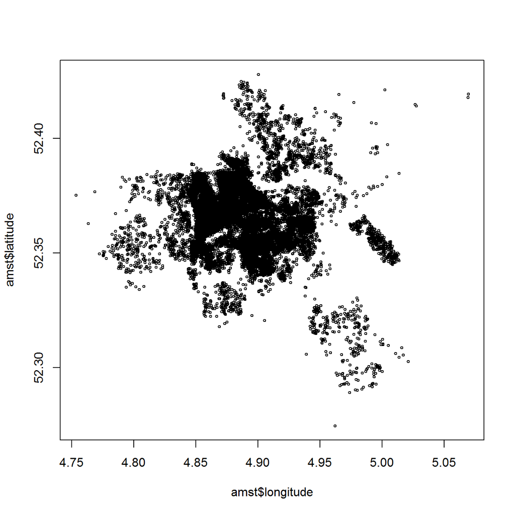

```r
plot(amst$longitude,amst$latitude,cex=0.5)  #cex controls the size of each point
```

We’ll revisit this data in an exercise!

### Reading Shapefiles

A shapefile consists of (as a minimum) three files with the same name but different extensions:

- `.shp` shape format
- `.shx` shape index format
- `.dbf` attributes (i.e. the data!)

There can be a number of other files included with a shapefile. All of these files should be **kept together**.

```r
nc_counties <- readOGR(dsn="shapefile",layer="NC_Counties")
```

Note that we set `dsn` to the folder containing the files making up the shapefile. This address **should not** have a `\` at the end.

```r
class(nc_counties)
```

```
## [1] "SpatialPolygonsDataFrame"
## attr(,"package")
## [1] "sp"
```

`nc_counties` is a `SpatialPolygonsDataFrame`. This indicates that the object contains both spatial polygons and underlying data. Let’s take a look with `summary`. It’s also possible to create `SpatialPolygons`, `SpatialPoints`, `SpatialPolygonsDataFrame`, and `SpatialPointsDataFrame` objects from scratch in R.

```r
summary(nc_counties[,1:8])
```

```
## Object of class SpatialPolygonsDataFrame
## Coordinates:
##         min      max
## x 123998.44 930357.7
## y  10468.16 318095.4
## Is projected: TRUE
## proj4string :
## [+proj=lcc +lat_1=34.33333333333334 +lat_2=36.16666666666666
## +lat_0=33.75 +lon_0=-79 +x_0=609601.22 +y_0=0 +datum=NAD83
## +units=m +no_defs +ellps=GRS80 +towgs84=0,0,0]
## Data attributes:
##         NAME             STATE_NAME  STATE_FIPS   CNTY_FIPS       FIPS
##  Alamance : 1   North Carolina:100   37:100     001    : 1   37001  : 1
##  Alexander: 1                                   003    : 1   37003  : 1
##  Alleghany: 1                                   005    : 1   37005  : 1
##  Anson    : 1                                   007    : 1   37007  : 1
##  Ashe     : 1                                   009    : 1   37009  : 1
##  Avery    : 1                                   011    : 1   37011  : 1
##  (Other)  :94                                   (Other):94   (Other):94
##       AREA          POP2000          POP2001
##  Min.   :174.0   Min.   :  4149   10451  : 1
##  1st Qu.:354.7   1st Qu.: 24099   10603  : 1
##  Median :467.5   Median : 47879   10851  : 1
##  Mean   :493.6   Mean   : 80493   113804 : 1
##  3rd Qu.:598.3   3rd Qu.: 91559   11570  : 1
##  Max.   :953.6   Max.   :695454   120465 : 1
##                                   (Other):94
```

Note the `Is Projected: TRUE` line towards the top of the summary. This indicates that the data is stored in a **projected coordinate system**. Projected coordinates project spherical coordinates into a two-dimensional space. They are often accurate for a specific area, but cause distortions on a larger scale (think about the various ways the entire world is often represented on a map).

**Geographic coordinates** are spherical; the most common example is latitude and longitude. You’ll often find data provided in different coordinate systems.

We can get another view of the coordinate system that contains more familiar information with:

```r
showWKT(proj4string(nc_counties))
```

```
## [1] "PROJCS[\"Lambert_Conformal_Conic\",GEOGCS[\"GCS_North_American_1983\",DATUM[\"D_North_American_1983\",SPHEROID[\"GRS_1980\",6378137,298.257222101]],PRIMEM[\"Greenwich\",0],UNIT[\"Degree\",0.017453292519943295]],PROJECTION[\"Lambert_Conformal_Conic\"],PARAMETER[\"standard_parallel_1\",34.3333…
```

The PROJC2, Lambert Conformal Conic, describes the projection used, and GEOGCS, gives the underlying geographic coordinate system, GCS North American 1983 is also known as NAD83.

Read more about projected and geographic coordinate systems [here](http://resources.esri.com/help/9.3/arcgisengine/dotnet/89b720a5-7339-44b0-8b58-0f5bf2843393.htm).

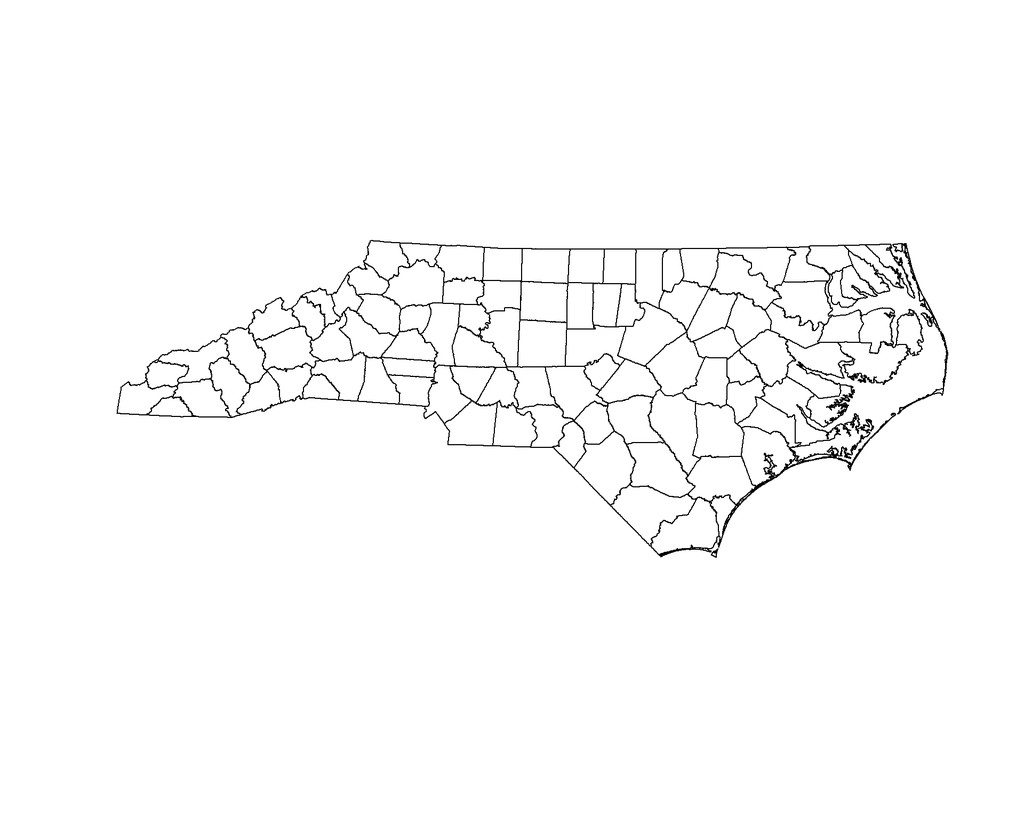

```r
plot(nc_counties)
```

### (Creating Shapefiles)

We can also create shapefiles and other spatial data types with `rgdal`. First, we need to point out which fields contain the coordinates, and define the coordinate system.

```r
amst_shp <- amst
coordinates(amst_shp) <- ~longitude+latitude
proj4string(amst_shp) <- CRS("+init=epsg:4326")
#writeOGR(amst_shp,dsn="shapefile","Amst_AirBnB",driver="ESRI Shapefile")
```

Note: Shapefiles require variable names less than 10 characters. If your variables have longer names, `writeOGR` will truncate them.

### Reading File Geodatabases

File geodatabases are stored in folders ending with .gdb. Your computer treats a geodatabase as a folder with many cryptic looking files inside. (Try opening nc_data.gdb with Windows Explorer or Finder.) It’s important not to change or move any of these component files. We’ll use R to determine what’s actually contained in our geodatabase.

```r
fgdb <- "nc_data.gdb"

# List all feature classes in a file geodatabase
print(ogrListLayers(fgdb))
```

```
## [1] "nc_cities" "nc_gas"
## attr(,"driver")
## [1] "OpenFileGDB"
## attr(,"nlayers")
## [1] 2
```

The available layers in this geodatabase are nc_cities and nc_gas (listed in the first row).

```r
nc_cities <- readOGR(dsn=fgdb,layer="nc_cities")
class(nc_cities)
```

```
## [1] "SpatialPointsDataFrame"
## attr(,"package")
## [1] "sp"
```

`nc_cities` is a `SpatialPointsDataFrame`. Similarly to the `nc_counties` layer above, this indicates that the layer countains spatial points along with underlying data.

```r
#summary(nc_cities)
```

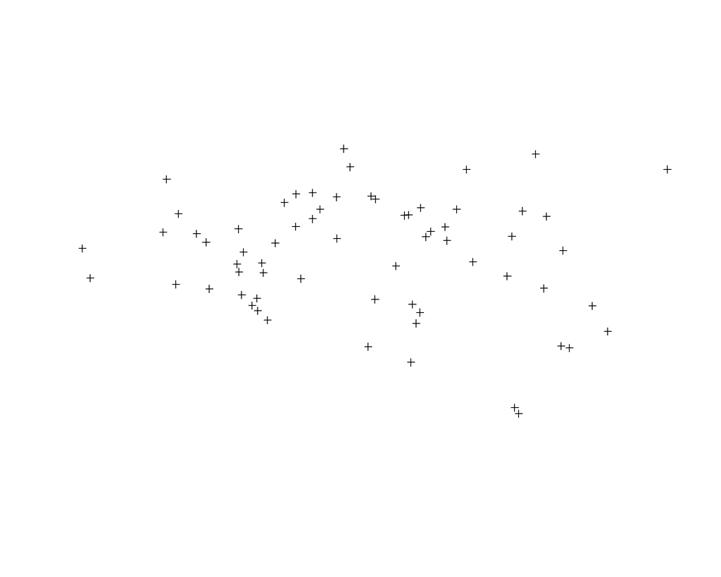

```r
plot(nc_cities)
```

We can quickly plot two layers together using the `add` parameter (provided they have compatible coordinate systems).

```r
nc_gas <- readOGR(dsn=fgdb,layer="nc_gas")
```

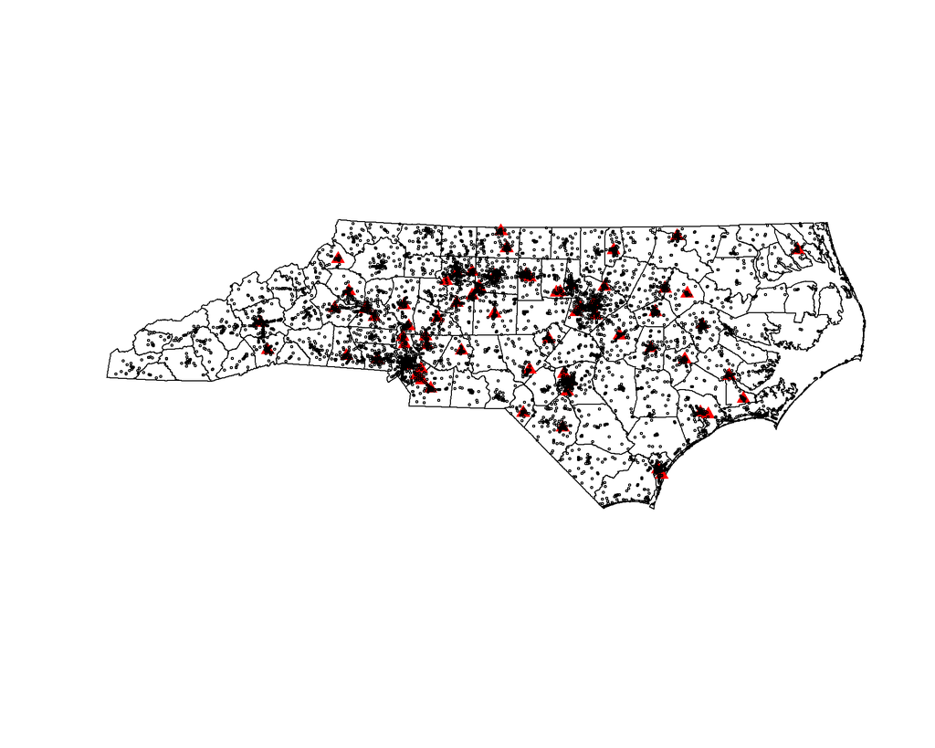

```r
plot(nc_counties)
plot(nc_cities,pch=17,cex=1.5,col="red",add=TRUE)
plot(nc_gas,pch=1,add=TRUE,cex=0.4)
```

### Adding basemaps with ggmap

#### Changing coordinate systems

Before adding a basemap, we need to convert it to a geographic coordinate system. We’ll use WGS84, which is encoded by “+init=epsg:4326”. The ESPG number is just one way to specify a particular coordinate system.

```r
nc_counties_wgs <- spTransform(nc_counties, CRS("+init=epsg:4326"))
```

With the geographic (i.e. latitude and longitude) coordinates set, we can use the layer to determine a suitable extent for a basemap with `bbox`, then download the map with `getmap`.

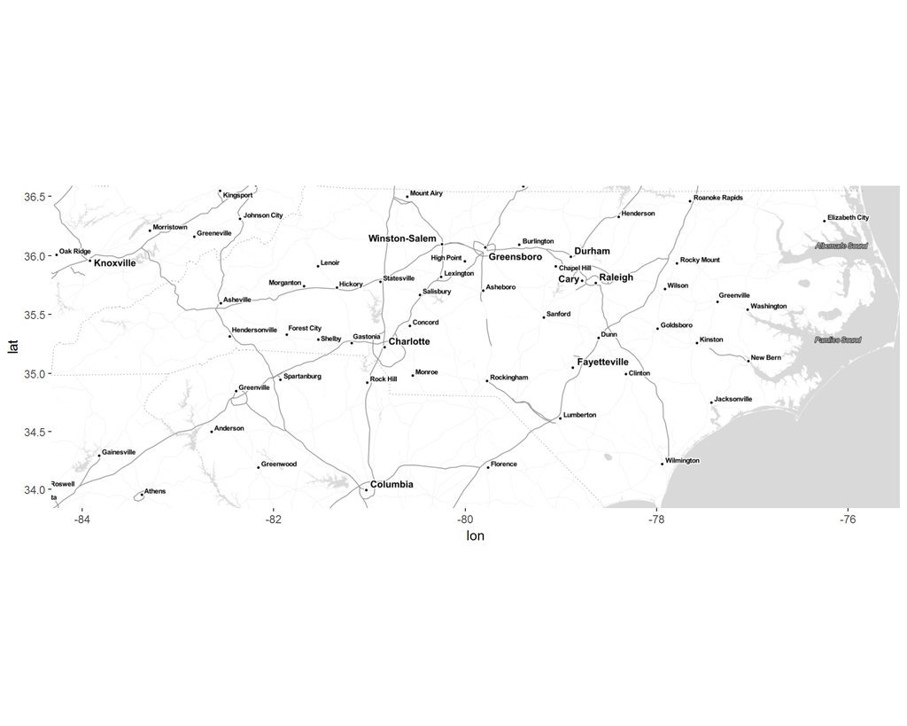

```r
b <- bbox(nc_counties_wgs)
base <- ggmap(get_map(location = b,source="stamen",maptype="toner-lite"))
base
```

#### Reformatting our polygons

However, to actually plot our polygon data, we need to convert the data into a data.frame format with the `fortify` function to work with `ggplot`. We need to specify the `region` option to control what field is used as a feature `id` in the output.

```r
nc_counties_wgs.f <- fortify(nc_counties_wgs,region="CNTY_FIPS")


class(nc_counties_wgs)
```

```
## [1] "SpatialPolygonsDataFrame"
## attr(,"package")
## [1] "sp"
```

```r
class(nc_counties_wgs.f)
```

```
## [1] "data.frame"
```

```r
head(nc_counties_wgs.f)
```

```
##        long      lat order  hole piece  id group
## 1 -79.25710 36.24384     1 FALSE     1 001 001.1
## 2 -79.25717 36.24279     2 FALSE     1 001 001.1
## 3 -79.25706 36.24262     3 FALSE     1 001 001.1
## 4 -79.25699 36.24245     4 FALSE     1 001 001.1
## 5 -79.25693 36.24218     5 FALSE     1 001 001.1
## 6 -79.25690 36.24196     6 FALSE     1 001 001.1
```

`fortify` produces a standard output, and only includes the spatial information, not the underlying data. We need to merge that back into the data.frame with `merge`. Since we set `region="CNTY_FIPS"` above, we know we can merge on `CNTY_FIPS`/`id`.

```r
nc_counties_wgs.f <- merge(nc_counties_wgs.f,nc_counties,by.x="id",by.y="CNTY_FIPS")
names(nc_counties_wgs.f)
```

```
##  [1] "id"         "long"       "lat"        "order"      "hole"
##  [6] "piece"      "group"      "NAME"       "STATE_NAME" "STATE_FIPS"
## [11] "FIPS"       "AREA"       "POP2000"    "POP2001"    "POP00_SQMI"
## [16] "WHITE"      "BLACK"      "AMERI_ES"   "ASIAN"      "HAWN_PI"
## [21] "OTHER"      "MULT_RACE"  "HISPANIC"   "MALES"      "FEMALES"
## [26] "AGE_UNDER5" "AGE_5_17"   "AGE_18_21"  "AGE_22_29"  "AGE_30_39"
## [31] "AGE_40_49"  "AGE_50_64"  "AGE_65_UP"  "MED_AGE"    "MED_AGE_M"
## [36] "MED_AGE_F"  "HOUSEHOLDS" "AVE_HH_SZ"  "HSEHLD_1_M" "HSEHLD_1_F"
## [41] "MARHH_CHD"  "MARHH_NO_C" "MHH_CHILD"  "FHH_CHILD"  "FAMILIES"
## [46] "AVE_FAM_SZ" "HSE_UNITS"  "VACANT"     "OWNER_OCC"  "RENTER_OCC"
## [51] "NO_FARMS97" "AVG_SIZE97" "CROP_ACR97" "AVG_SALE97"
```

Now we can use ggplot syntax with `geom_polygon` to plot our polygons.

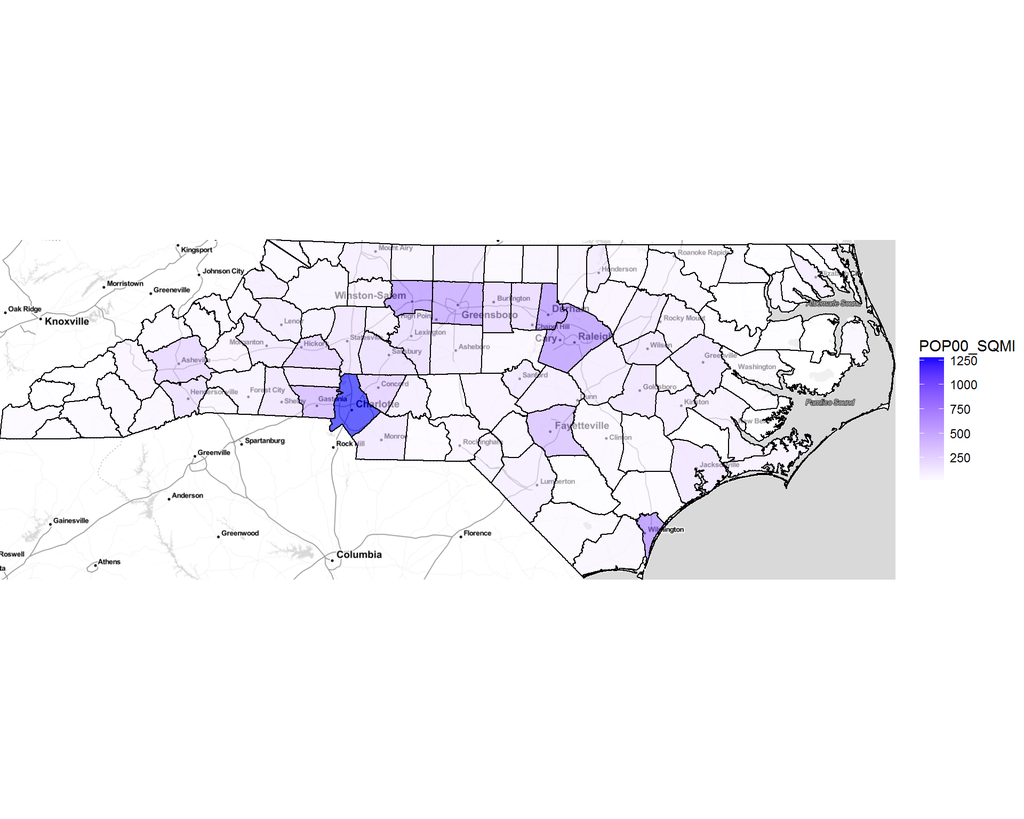

```r
p1 <- base+
  geom_polygon(data=nc_counties_wgs.f,
               aes(x=long,y=lat,group=group,fill=POP00_SQMI),alpha=0.6,color="black",size=0.5)+
  scale_fill_gradient(low="white",high="blue")+
  theme_nothing(legend = TRUE)

p1
```

#### Adding Spatial Points

Spatial points do not need to be fortified since they only need one line per observation. Instead, we only need to make sure they use the same coordinate system, then convert them to a dataframe with `as.data.frame`. The `SpatialPointsDataFrame` object will place their longitude in `coords.x1` and their latitude in `coords.x2`.

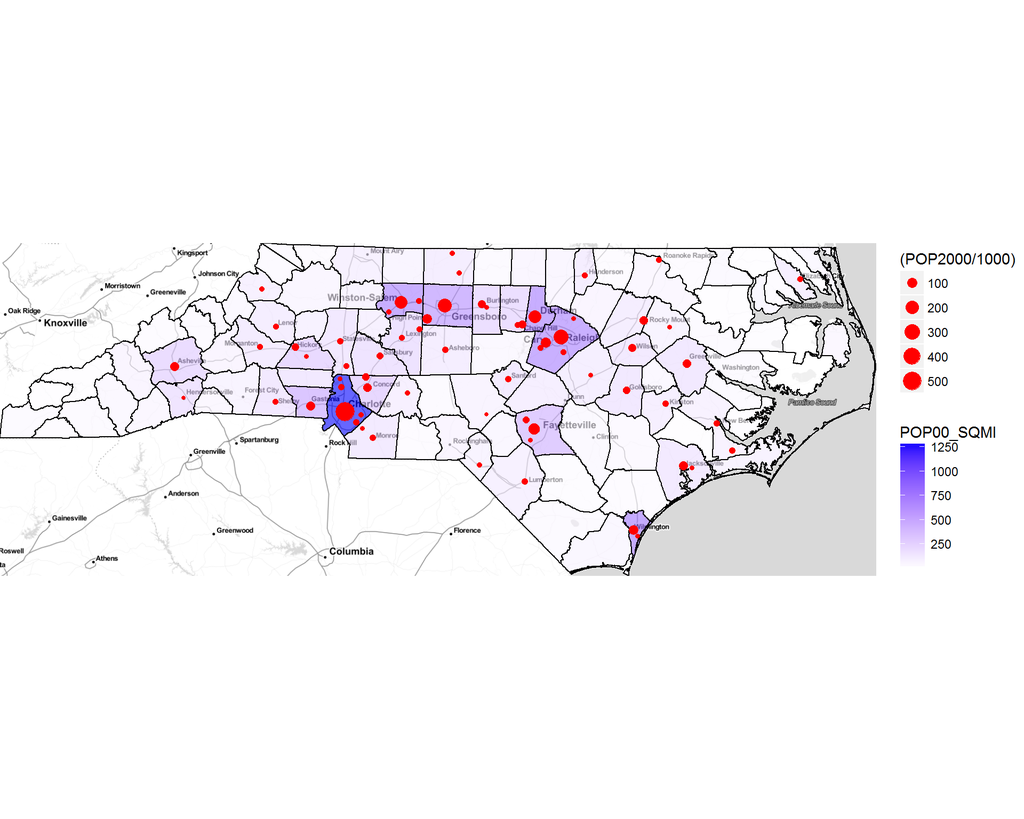

```r
nc_cities_wgs <- spTransform(nc_cities, CRS("+init=epsg:4326"))
nc_cities_wgs.df <- as.data.frame(nc_cities_wgs)

p1+geom_point(data=nc_cities_wgs.df,aes(x=coords.x1,y=coords.x2,size=(POP2000/1000)),colour="red")
```

## Read More

[Introduction to visualizing spatial data in R](https://cran.r-project.org/doc/contrib/intro-spatial-rl.pdf)

[Spatial Data Analysis and Modeling with R](http://rspatial.org/index.html)

[Applied spatial data analysis with R (Book)](http://search.lib.unc.edu/search?R=UNCb7432836)

## Exercises

1. How might you change the county-level population density plot to only plot counties with a median age less than or equal to 35?
2. Return to the Amsterdam AirBnB data, using either the data derived from the csv or the layer AirBnB in the amsterdam.gdb. Use `ggmap` to plot it against a basemap.
3. Add the Parks layer to your Amsterdam map. Plot a new map with only the Airbnb locations with a price less than or equal to 100.

**[Let us know what you think of this session!](https://unc.az1.qualtrics.com/jfe/form/SV_8e1zRY2rlFUYBMx)**

### Data Sources

[City of Amsterdam Maps Data](https://maps.amsterdam.nl/open_geodata/)

[insideairbnb.com](http://insideairbnb.com/get-the-data.html)